# sbux-ceo-change

### This is a simplified example project showcasing a multiple causal inference models that you can use with readily available data and that is highly transferable for industry-related questions.

### In Aug 2024, Starbucks announced a CEO change without any other materially confounding information (e.g. it wasn't along an earnings report). Events like these are something companies and investors are regularly interested in quantifying impact -- but naturally don't want to design an experiment randomly giving users bad experiences

### Examples of how this might transfer: Suppose there is an outage that affects a certain region or population of users (iOs but not Android, NYC but not San Francisco or LA, purchasers of product X but not Y, etc.). If you have a time series of performance by these groups, you may consider these models to estimate the impact.

### Note this is a simplified example. E.g. we look at one-day returns on the event date (common in litigation economics), but price movements suggest you may be interested in longer periods. Other methods may provide better results in placebo testing such as synthetic controls or event study models. A data scientist or economist should perform deeper research to determine the best research design.

```python
import pandas as pd
import numpy as np
import matplotlib.pyplot as plt
import datetime
import statsmodels.formula.api as smf
from yahoo_fin import stock_info as si
```

```python
def get_daily_prices(ticker, start_date, end_date):
    df = si.get_data(ticker,interval='1d',start_date=start_date, end_date=end_date,index_as_date=False)
    df['price']=df['adjclose']
    df=df[['date','price','ticker']]
    return df

def get_prices(tickerlist,start, end):
    df=pd.DataFrame(columns=['date','price','ticker'])
    for ticker in tickerlist:
        df=pd.concat([df,get_daily_prices(ticker, start, end)])
    return df

def run_diff_in_diff(df, event_date, treated):
    start_date = event_date - datetime.timedelta(days=180)
    df = df[(df['date'] >= start_date) & (df['date'] <= event_date) & (df['returns'].isnull()==0)].copy()
    df['treated'] = np.where(df['ticker']==treated, 1, 0)
    df['post'] = np.where(df['date']>=event_date, 1, 0)
    df['treated_post'] = df['treated'] * df['post']

    formula = "returns ~ treated + post + treated_post"
    model = smf.ols(formula=formula, data=df).fit()
    return model


def difference_in_trends(df, event_date, treated):
    start_date = event_date - datetime.timedelta(days=180)
    df = df[(df['date'] >= start_date) & (df['date'] <= event_date)].copy()
    df['treated'] = np.where(df['ticker']==treated, 1, 0)
    df['trend'] = (event_date - df['date']).dt.days
    df['treated_trend'] = df['treated']*df['trend']
    formula = "returns ~ treated + trend + treated_trend"
    model = smf.ols(formula=formula, data=df).fit()
    return model


def plot_histogram(df, model, param, mytitle):
    quantile_2_5 = df['betas'].quantile(0.025)
    quantile_97_5 = df['betas'].quantile(0.975)
    model_est = model.params[param]

    plt.hist(df['betas'], bins=10, alpha=0.7)
    plt.axvline(quantile_2_5, color='black', linestyle='--', linewidth=1, label='2.5th pctl')
    plt.axvline(quantile_97_5, color='black', linestyle='--', linewidth=1, label='97.5th pctl')
    plt.axvline(model_est, color='red', linestyle='--', linewidth=1, label='Event Impact')
    plt.legend(loc='upper left')
    plt.title(mytitle)
    plt.show()


def get_event_study_placebos(df_wide, pre_event_dates, cutoff_days, formula):
    pvalues = list()
    betas = list()

    for placebo_date in pre_event_dates:
        cutoff = pd.to_datetime(placebo_date) - datetime.timedelta(days=cutoff_days)
        placebo_df = df_wide[(df_wide['date'] >= cutoff) & (df_wide['date'] <= placebo_date)].copy()
        placebo_df['event'] = np.where(placebo_df['date']==placebo_date,1,0)
        placebo_model=smf.ols(formula=formula, data=placebo_df).fit()
        pvalues.append(placebo_model.pvalues['event'])
        betas.append(placebo_model.params['event'])

    placebo_estimates = pd.DataFrame({'betas':betas, 'pvalues':pvalues})
    rmse = np.sqrt((placebo_estimates['betas']**2).mean())

    return(placebo_estimates,rmse)
```

```python
# start_date = '01-01-2024'
# end_date = '08-15-2024'
# df=pd.DataFrame()
# for ticker in list(['SBUX','VOO','QSR','YUM','MCD']):
#     df=pd.concat([df,si.get_data(ticker,interval='1d',start_date=start_date, end_date=end_date,index_as_date=False)])
# print(df)

# df['returns'] = np.where(df['ticker']==df['ticker'].shift(),
#                             (df['close']/df['close'].shift())-1, np.nan)
# df.to_csv('sbux_ceo_prices.csv', index=False)

event_date = '2024-08-13'
prices = pd.read_csv('sbux_ceo_prices.csv')
prices = prices[prices['returns'].isnull()==0].copy()
prices.head()
```

|  | date | ticker | close | open | high | low | adjclose | volume | returns |
| --- | --- | --- | --- | --- | --- | --- | --- | --- | --- |
| 1 | 2024-01-03 | SBUX | 93.230003 | 93.959999 | 94.239998 | 93.059998 | 91.422096 | 7161700.0 | -0.004697 |
| 2 | 2024-01-04 | SBUX | 93.550003 | 93.099998 | 94.580002 | 93.000000 | 91.735893 | 7118600.0 | 0.003432 |
| 3 | 2024-01-05 | SBUX | 92.989998 | 93.330002 | 93.580002 | 92.480003 | 91.186745 | 7189900.0 | -0.005986 |
| 4 | 2024-01-08 | SBUX | 94.190002 | 93.019997 | 94.570000 | 92.949997 | 92.363472 | 7536900.0 | 0.012905 |
| 5 | 2024-01-09 | SBUX | 93.089996 | 93.610001 | 93.730003 | 92.860001 | 91.284798 | 6348500.0 | -0.011679 |

```python
total_shares = 1132800000

pre = prices[prices['date']<event_date].copy()
lastprice = pre.loc[(pre['date']==max(pre['date'])) & (pre['ticker']=='SBUX'),'close'].values[0]
lastmarketvalue = lastprice * total_shares
print(f"Last Market Value: $ {round(lastmarketvalue)}")

prices[prices['date']<event_date].groupby(['ticker'])['returns'].agg(['count','mean','std'])
```

```
Last Market Value: $ 87259582617
```

| ticker | count | mean | std |
| --- | --- | --- | --- |
| MCD | 153 | -0.000568 | 0.011725 |
| QSR | 153 | -0.000522 | 0.014667 |
| SBUX | 153 | -0.001079 | 0.019548 |
| VOO | 153 | 0.000826 | 0.007927 |
| YUM | 153 | 0.000379 | 0.010292 |

### Estimate event study model

```python
df_wide = prices.pivot(index='date', columns='ticker', values='returns')
df_wide.reset_index(inplace=True)
df_wide.columns.name = None
df_wide['date'] = pd.to_datetime(df_wide['date'])
df_wide.head()
```

|  | date | MCD | QSR | SBUX | VOO | YUM |
| --- | --- | --- | --- | --- | --- | --- |
| 0 | 2024-01-03 | -0.008921 | -0.005985 | -0.004697 | -0.007419 | 0.000543 |
| 1 | 2024-01-04 | -0.009002 | -0.000916 | 0.003432 | -0.003157 | -0.003176 |
| 2 | 2024-01-05 | -0.009426 | 0.001310 | -0.005986 | 0.001281 | -0.002720 |
| 3 | 2024-01-08 | 0.010070 | 0.022635 | 0.012905 | 0.014303 | 0.002338 |
| 4 | 2024-01-09 | -0.003529 | -0.003199 | -0.011679 | -0.002430 | -0.003265 |

```python
cutoff_days = 120
event_date = pd.to_datetime(event_date)
cutoff = event_date - datetime.timedelta(days=cutoff_days)
df = df_wide[(df_wide['date'] >= cutoff) & (df_wide['date'] <= event_date)].copy()
df['event'] = np.where(df['date']==event_date,1,0)


formula = 'SBUX~MCD+QSR+VOO+YUM+event'
model = smf.ols(formula=formula, data=df).fit()
print(model.summary())
```

```
                            OLS Regression Results
==============================================================================
Dep. Variable:                   SBUX   R-squared:                       0.670
Model:                            OLS   Adj. R-squared:                  0.649
Method:                 Least Squares   F-statistic:                     31.66
Date:                Fri, 30 Aug 2024   Prob (F-statistic):           1.81e-17
Time:                        19:34:03   Log-Likelihood:                 206.12
No. Observations:                  84   AIC:                            -400.2
Df Residuals:                      78   BIC:                            -385.7
Df Model:                           5
Covariance Type:            nonrobust
==============================================================================
                 coef    std err          t      P>|t|      [0.025      0.975]
------------------------------------------------------------------------------
Intercept     -0.0006      0.002     -0.242      0.809      -0.005       0.004
MCD           -0.2654      0.233     -1.138      0.259      -0.730       0.199
QSR            0.3962      0.190      2.088      0.040       0.019       0.774
VOO           -0.0934      0.297     -0.314      0.754      -0.685       0.498
YUM            0.9978      0.265      3.761      0.000       0.470       1.526
event          0.2287      0.022     10.259      0.000       0.184       0.273
==============================================================================
Omnibus:                       31.439   Durbin-Watson:                   2.296
Prob(Omnibus):                  0.000   Jarque-Bera (JB):              187.864
Skew:                          -0.854   Prob(JB):                     1.61e-41
Kurtosis:                      10.124   Cond. No.                         138.
==============================================================================

Notes:
[1] Standard Errors assume that the covariance matrix of the errors is correctly specified.
```

```python
print("Estimated Gain: ${:,}".format(round(lastmarketvalue*model.params['event'])))
```

```
Estimated Gain: $19,955,241,349
```

```
RMSE: 0.025
```

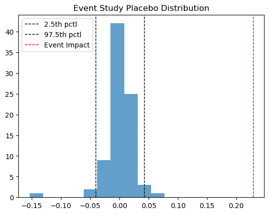

```python
placebo_start = event_date - datetime.timedelta(days=120)
pre_event_dates = df_wide[(df_wide['date'] >= placebo_start) & (df_wide['date'] < event_date)]['date'].unique()
mytitle = "Event Study Placebo Distribution"
placebo_estimates, rmse = get_event_study_placebos(df_wide, pre_event_dates, cutoff_days, formula)

print(f"RMSE: {rmse:.3f}")
plot_histogram(placebo_estimates, model,"event", mytitle)
```

## Estimate Difference-in-Differences Model

```python
event_date = pd.to_datetime(event_date)
treated = 'SBUX'

prices['date'] = pd.to_datetime(prices['date'])
model = run_diff_in_diff(prices, event_date, treated)
print(model.summary())
```

```
                            OLS Regression Results
==============================================================================
Dep. Variable:                returns   R-squared:                       0.339
Model:                            OLS   Adj. R-squared:                  0.336
Method:                 Least Squares   F-statistic:                     105.2
Date:                Fri, 30 Aug 2024   Prob (F-statistic):           5.40e-55
Time:                        19:34:04   Log-Likelihood:                 1774.3
No. Observations:                 620   AIC:                            -3541.
Df Residuals:                     616   BIC:                            -3523.
Df Model:                           3
Covariance Type:            nonrobust
================================================================================
                   coef    std err          t      P>|t|      [0.025      0.975]
--------------------------------------------------------------------------------
Intercept    -9.701e-05      0.001     -0.155      0.877      -0.001       0.001
treated         -0.0013      0.001     -0.925      0.355      -0.004       0.001
post             0.0117      0.007      1.679      0.094      -0.002       0.025
treated_post     0.2347      0.016     15.063      0.000       0.204       0.265
==============================================================================
Omnibus:                      393.962   Durbin-Watson:                   2.064
Prob(Omnibus):                  0.000   Jarque-Bera (JB):            19739.502
Skew:                          -2.129   Prob(JB):                         0.00
Kurtosis:                      30.313   Cond. No.                         29.3
==============================================================================

Notes:
[1] Standard Errors assume that the covariance matrix of the errors is correctly specified.
```

## Test Validation Assumptions

### Distribution of placebo diff-in-diff results

```
RMSE: 0.022
```

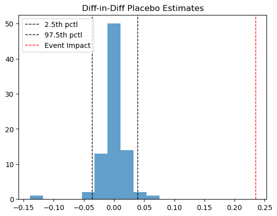

```python
placebo_start = event_date - datetime.timedelta(days=120)
prices['date'] = pd.to_datetime(prices['date'])
pre_event_dates = prices[(prices['date'] >= placebo_start) & (prices['date'] < event_date)]['date'].unique()
pvalues = list()
betas = list()


for placebo_date in pre_event_dates:
    placebo_model=run_diff_in_diff(prices, pd.to_datetime(placebo_date), treated)
    pvalues.append(placebo_model.pvalues['treated_post'])
    betas.append(placebo_model.params['treated_post'])

df = pd.DataFrame({'betas':betas, 'pvalues':pvalues})
rmse = np.sqrt((df['betas']**2).mean())
print(f"RMSE: {rmse:.3f}")

mytitle = "Diff-in-Diff Placebo Estimates"
plot_histogram(df, model, "treated_post", mytitle)
```

```python
print("Estimated Gain: ${:,}".format(round(lastmarketvalue*model.params['treated_post'])))
```

```
Estimated Gain: $20,476,849,918
```